# Análisis Multidimensional de Indicadores Educativos

Reporte Estadístico

2026-08-28

## Resumen del Dataset

Este reporte presenta una evaluación completa de múltiples variables e indicadores de cobertura, aprobación, reprobación, repitencia y deserción del sector educativo. El análisis discrimina adecuadamente las variables categóricas de las numéricas, normaliza los datos continuos y explora las distribuciones, valores atípicos y correlaciones estadísticas de interés.

## 1. Preparación del Entorno y Carga de Datos

En esta etapa inicial, se importan los datos aplicando una distinción estricta de los separadores de archivo (comas para dividir columnas) y los delimitadores de decimales (puntos). Luego, con base en el entendimiento funcional (diccionario de datos), reclasificamos las variables geográficas que originalmente son numéricas (Códigos DANE) como categóricas (factores).

```r
# Cargar librerías necesarias
library(ggplot2)
library(dplyr)
library(tidyr)
library(reshape2)
library(knitr)

# Crear carpeta para guardar todos los resultados
dir.create("resultados taller 1", showWarnings = FALSE)

# 1. Carga de datos con parámetros explícitos (sep para comas de archivo, dec para decimales)
datos <- read.csv("data/EDUCACION_LIMPIO.csv", sep = ",", dec = ".")

# 2. Análisis y Tipificación según "Diccionario de Datos":
# Convertimos las entidades geográficas a factores (categóricas) ya que no son magnitudes numéricas reales.
datos$CÓDIGO_MUNICIPIO <- as.factor(datos$CÓDIGO_MUNICIPIO)
datos$CÓDIGO_DEPARTAMENTO <- as.factor(datos$CÓDIGO_DEPARTAMENTO)

# Filtramos estrictamente las variables numéricas (cuantitativas reales) para el análisis estadístico
variables_numericas <- datos %>% select(where(is.numeric))
```

## 2. Tabla de Resumen Estadístico (Variables Clave)

La siguiente tabla consolida las estadísticas descriptivas para todas las variables cuantitativas del modelo.

```r
# Cálculo de estadísticas clave
resumen <- data.frame(
  Variable = names(variables_numericas),
  Media = sapply(variables_numericas, mean, na.rm = TRUE),
  Desv_Est = sapply(variables_numericas, sd, na.rm = TRUE),
  Mínimo = sapply(variables_numericas, min, na.rm = TRUE),
  Mediana = sapply(variables_numericas, median, na.rm = TRUE),
  Máximo = sapply(variables_numericas, max, na.rm = TRUE)
)

# Exportar los resultados a CSV
write.csv(resumen, "resultados taller 1/Resumen_Estadistico.csv", row.names = FALSE)

# Renderización de tabla en HTML
kable(resumen, digits = 3, caption = "Resumen Estadístico de las Variables Numéricas", row.names = FALSE)
```

Resumen Estadístico de las Variables Numéricas

| Variable | Media | Desv_Est | Mínimo | Mediana | Máximo |
| --- | --- | --- | --- | --- | --- |
| POBLACIÓN_5_16 | 3143.451 | 2819.803 | 1.005 | 2220.000 | 14013.000 |
| TASA_MATRICULACIÓN_5_16 | 0.832 | 0.127 | 0.454 | 0.837 | 1.235 |
| COBERTURA_NETA | 0.841 | 0.115 | 0.513 | 0.851 | 1.170 |
| COBERTURA_NETA_TRANSICIÓN | 0.575 | 0.134 | 0.206 | 0.575 | 0.946 |
| COBERTURA_NETA_PRIMARIA | 0.810 | 0.120 | 0.479 | 0.813 | 1.156 |
| COBERTURA_NETA_SECUNDARIA | 0.715 | 0.130 | 0.342 | 0.715 | 1.076 |
| COBERTURA_NETA_MEDIA | 0.431 | 0.121 | 0.076 | 0.435 | 0.762 |
| COBERTURA_BRUTA | 0.947 | 0.141 | 0.552 | 0.953 | 1.356 |
| COBERTURA_BRUTA_TRANSICIÓN | 0.822 | 0.177 | 0.348 | 0.819 | 1.348 |
| COBERTURA_BRUTA_PRIMARIA | 1.001 | 0.176 | 0.534 | 1.000 | 1.478 |
| COBERTURA_BRUTA_SECUNDARIA | 1.006 | 0.181 | 0.516 | 1.006 | 1.497 |
| COBERTURA_BRUTA_MEDIA | 0.758 | 0.187 | 0.237 | 0.758 | 1.280 |
| DESERCIÓN | 0.030 | 0.016 | 0.000 | 0.028 | 0.083 |
| DESERCIÓN_TRANSICIÓN | 0.029 | 0.021 | 0.000 | 0.026 | 0.095 |
| DESERCIÓN_PRIMARIA | 0.023 | 0.015 | 0.000 | 0.020 | 0.070 |
| DESERCIÓN_SECUNDARIA | 0.041 | 0.024 | 0.000 | 0.037 | 0.114 |
| DESERCIÓN_MEDIA | 0.028 | 0.019 | 0.000 | 0.025 | 0.084 |
| APROBACIÓN | 0.934 | 0.037 | 0.809 | 0.936 | 1.000 |
| APROBACIÓN_TRANSICIÓN | 0.000 | 0.000 | 0.000 | 0.000 | 0.000 |
| APROBACIÓN_PRIMARIA | 0.948 | 0.034 | 0.832 | 0.953 | 1.000 |
| APROBACIÓN_SECUNDARIA | 0.905 | 0.059 | 0.698 | 0.911 | 1.000 |
| APROBACIÓN_MEDIA | 0.941 | 0.037 | 0.818 | 0.946 | 1.000 |
| REPROBACIÓN | 0.036 | 0.031 | 0.000 | 0.034 | 0.150 |
| REPROBACIÓN_TRANSICIÓN | 0.000 | 0.000 | 0.000 | 0.000 | 0.000 |
| REPROBACIÓN_PRIMARIA | 0.029 | 0.028 | 0.000 | 0.023 | 0.126 |
| REPROBACIÓN_SECUNDARIA | 0.055 | 0.051 | 0.000 | 0.048 | 0.239 |
| REPROBACIÓN_MEDIA | 0.031 | 0.030 | 0.000 | 0.023 | 0.125 |
| REPITENCIA | 0.024 | 0.022 | 0.000 | 0.018 | 0.101 |
| REPITENCIA_TRANSICIÓN | 0.003 | 0.006 | 0.000 | 0.000 | 0.024 |
| REPITENCIA_PRIMARIA | 0.023 | 0.023 | 0.000 | 0.016 | 0.099 |
| REPITENCIA_SECUNDARIA | 0.034 | 0.034 | 0.000 | 0.023 | 0.141 |
| REPITENCIA_MEDIA | 0.012 | 0.013 | 0.000 | 0.007 | 0.053 |

## 3. Histogramas para las Variables Numéricas

Se presentan las distribuciones individuales para evaluar la simetría, sesgos y concentración en cada indicador.

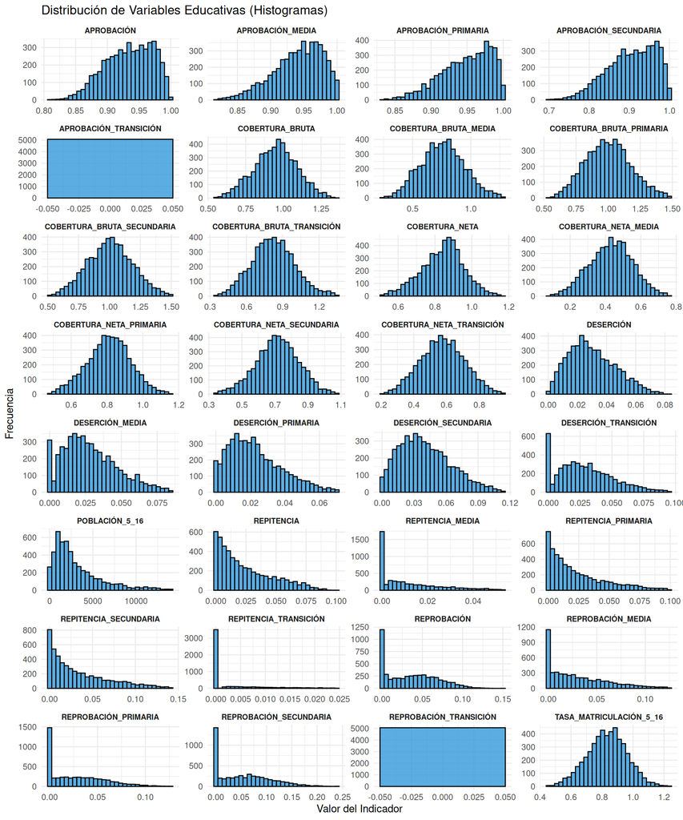

```r
# Transformar datos a formato largo para facilitar la graficación con facetas
datos_long <- variables_numericas %>%
  pivot_longer(cols = everything(), names_to = "Variable", values_to = "Valor")

# Graficar la cuadrícula de histogramas
p_hist <- ggplot(datos_long, aes(x = Valor)) +
  geom_histogram(bins = 30, fill = "#3498db", color = "black", alpha = 0.8) +
  facet_wrap(~ Variable, scales = "free", ncol = 4) +
  theme_minimal() +
  labs(
    title = "Distribución de Variables Educativas (Histogramas)",
    x = "Valor del Indicador",
    y = "Frecuencia"
  ) +
  theme(strip.text = element_text(size = 8, face = "bold"))

# Mostrar y guardar gráfico
print(p_hist)
```

```r
ggsave("resultados taller 1/Histogramas.png", plot = p_hist, width = 12, height = 10)
```

## 4. Normalización y Diagramas de Caja (Boxplots)

Para evaluar los indicadores en una escala comparable e identificar la presencia de valores atípicos (outliers), se aplica una normalización Min-Max (rango de [0, 1]) y se consolidan en diagramas de caja.

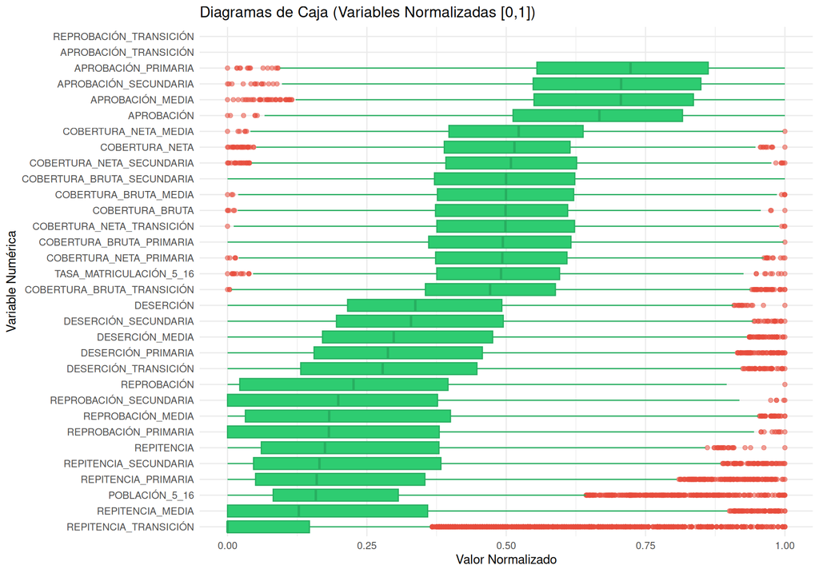

```r
# Función de normalización Min-Max
normalizar <- function(x) {
  return ((x - min(x, na.rm = TRUE)) / (max(x, na.rm = TRUE) - min(x, na.rm = TRUE)))
}

# Aplicar normalización a las variables numéricas
datos_norm <- variables_numericas %>% mutate(across(everything(), normalizar))

# Formato largo para los boxplots
datos_norm_long <- datos_norm %>%
  pivot_longer(cols = everything(), names_to = "Variable", values_to = "Valor_Normalizado")

# Graficar Boxplots unificados
p_box <- ggplot(datos_norm_long, aes(x = reorder(Variable, Valor_Normalizado, FUN = median, na.rm = TRUE), y = Valor_Normalizado)) +
  geom_boxplot(fill = "#2ecc71", color = "#27ae60", outlier.color = "#e74c3c", outlier.alpha = 0.5) +
  coord_flip() + # Voltear para mejorar la lectura de las etiquetas
  theme_minimal() +
  labs(
    title = "Diagramas de Caja (Variables Normalizadas [0,1])",
    x = "Variable Numérica",
    y = "Valor Normalizado"
  )

# Mostrar y guardar gráfico
print(p_box)
```

```r
ggsave("resultados taller 1/Boxplots.png", plot = p_box, width = 8, height = 10)
```

## 5. Relaciones Bivariadas (Diagramas de Dispersión)

Analizamos las interdependencias críticas entre indicadores seleccionados, evaluando su trayectoria y posibles tendencias lineales.

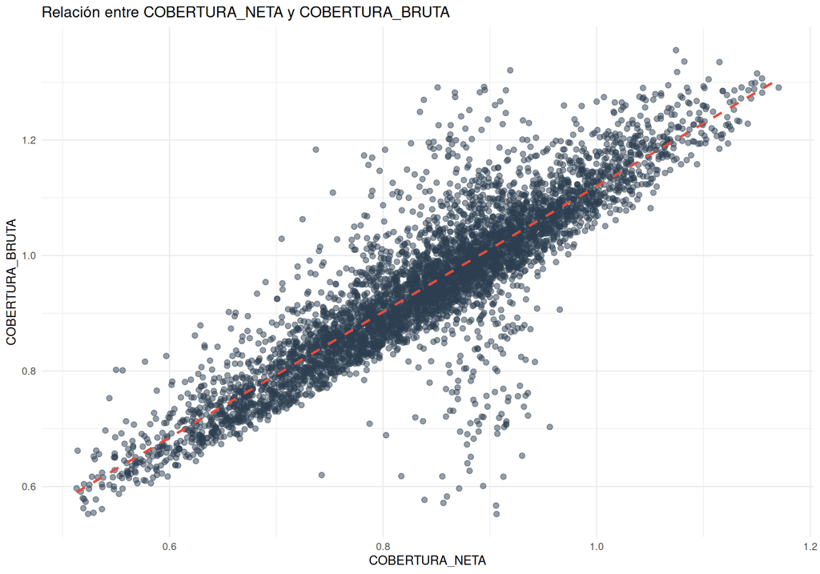

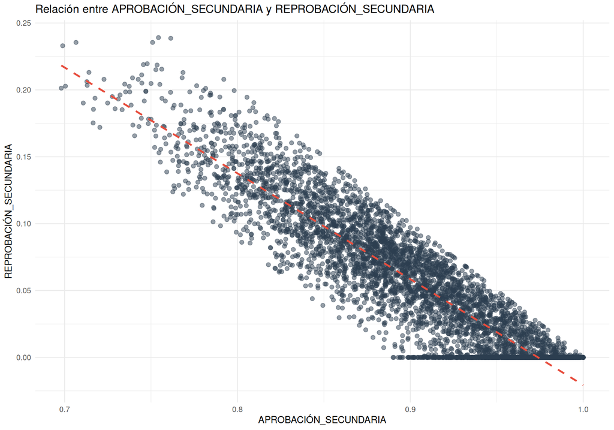

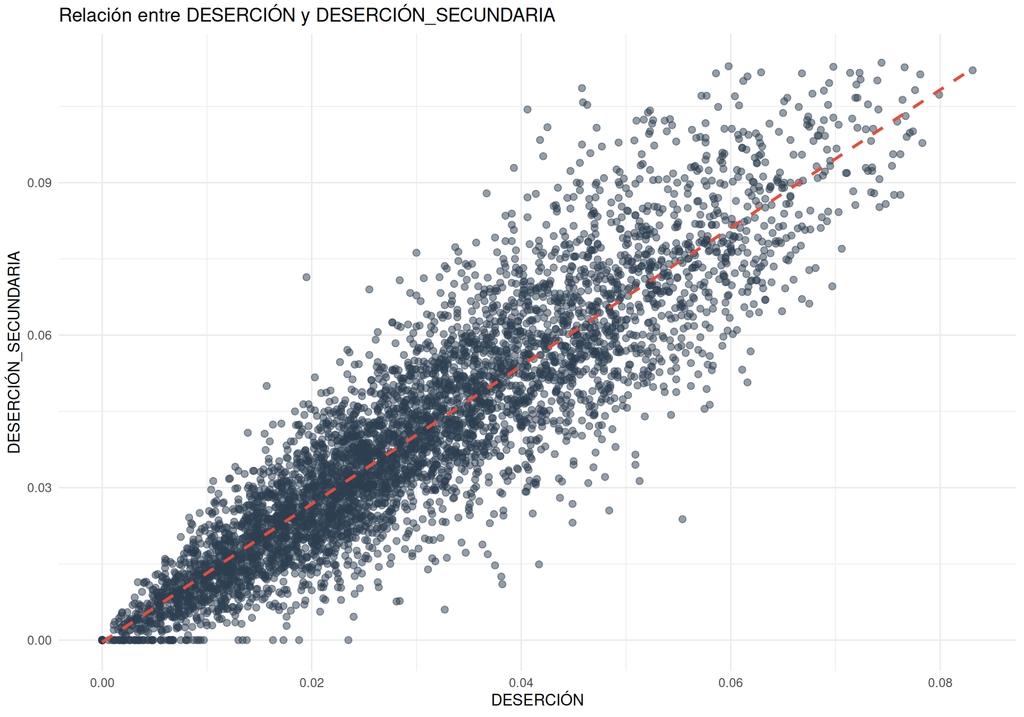

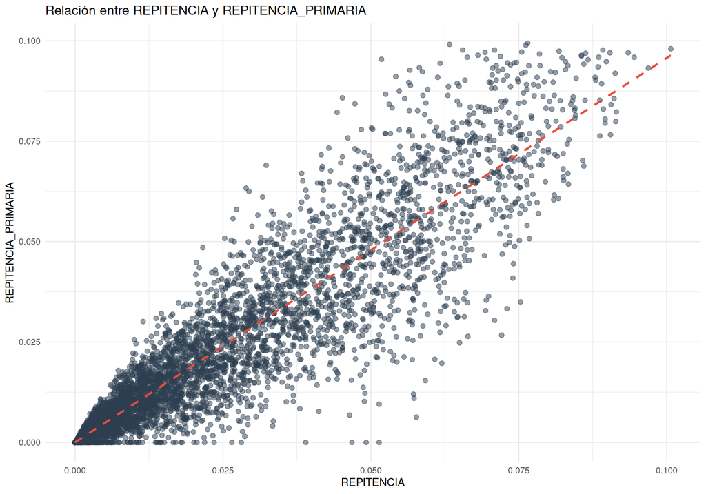

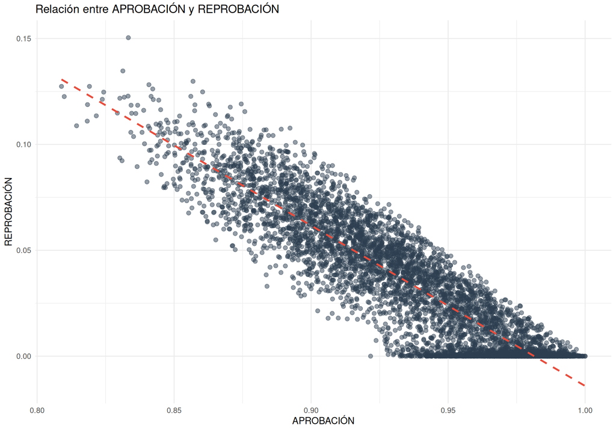

```r
# Definir los 5 pares de variables solicitados
pares <- list(
  c("COBERTURA_NETA", "COBERTURA_BRUTA"),
  c("APROBACIÓN_SECUNDARIA", "REPROBACIÓN_SECUNDARIA"),
  c("DESERCIÓN", "DESERCIÓN_SECUNDARIA"),
  c("REPITENCIA", "REPITENCIA_PRIMARIA"),
  c("APROBACIÓN", "REPROBACIÓN") # Quinto par añadido para complementar el análisis
)

# Generar gráficos secuenciales y exportarlos
for (i in 1:length(pares)) {
  var1 <- pares[[i]][1]
  var2 <- pares[[i]][2]

  if(var1 %in% names(datos) & var2 %in% names(datos)) {
    p <- ggplot(datos, aes_string(x = var1, y = var2)) +
      geom_point(alpha = 0.5, color = "#2c3e50", size = 2) +
      geom_smooth(method = "lm", color = "#e74c3c", se = FALSE, linetype = "dashed") +
      labs(
        title = paste("Relación entre", var1, "y", var2),
        x = var1,
        y = var2
      ) +
      theme_minimal()

    print(p)
    ggsave(paste0("resultados taller 1/Dispersion_", var1, "_vs_", var2, ".png"), plot = p, width = 6, height = 4)
  }
}
```